### 06 de Abril, 2021

## Projeto - Modelagem Preditiva em IoT - Previsão de Uso de Energia

Este projeto de IoT tem como objetivo a criação de modelos preditivos para a previsão de consumo de energia de eletrodomésticos. Os dados utilizados incluem medições de sensores de temperatura e umidade de uma rede sem fio, previsão do tempo de uma estação de um aeroporto e uso de energia utilizada por luminárias.

Cada nó sem fio transmitia as condições de temperatura e umidade em torno de 3 min. Em seguida, a média dos dados foi calculada para períodos de 10 minutos. Os dados de energia foram registrados a cada 10 minutos com medidores de energia de barramento m.

Este Projeto visa construir um modelo preditivo que possa prever o consumo de energia com base nos dados de sensores IoT coletados.

Dcionario dos dados

date: Tempo de coleta dos dados pelos sensores.

Appliances: Uso de energia (em W).

lights: Potência de energia de eletrodomésticos na casa (em W).

TX: Temperatura em um lugar da casa (em Celsius).

RH_X: Umidade relativa em algum ponto da casa (em %).

Press_mm_hg: Não foi informado.

Windspeed: Velocidade do vento (em m/s).

Visibility: Visibilidade (em Km).

Tdewpoint: Não foi informado.

rv1: Variável randômica adicional.

rv2: Variável randômica adicional.

WeekStatus: Indica se é dia de semana ou final de semana.

Day_of_week: Dia da semana.

NSM: Medida de tempo (em s).

## Carregando pacotes

```r
# Instalando os pacotes

#install.packages('tidyverse')
#install.packages('caret')
#install.packages('ROSE')
#install.packages('data.table')
#install.packages('gridExtra')
#install.packages('randomForest')
#install.packages('DMwR')
#install.packages('e1071')
#install.packages('rpart')
#install.packages('caTools')
#install.packages('kernlab')
#install.packages('xgboost')

# Carregando pacotes

library('tidyverse')
library('caret')
library('ROSE')
library('data.table')
library('gridExtra')
library('randomForest')
library('DMwR')
```

```r
library('e1071')
library('rpart')
library('caTools')
library('corrplot')
library('kernlab')
library('xgboost')
```

## Carregando os Dados

```r
# Carrego os datasets para análise.

df_train <- read_csv('Dados/projeto8-training.csv')
df_train <- as.data.frame(df_train)
df_test <- read_csv('Dados/projeto8-testing.csv')
df_test <- as.data.frame(df_test)

# Imprimo as primeiras linhas
head(df_train)
```

```
##                  date Appliances lights       T1     RH_1   T2     RH_2    T3
## 1 2016-01-11 17:00:00         60     30 19.89000 47.59667 19.2 44.79000 19.79
## 2 2016-01-11 17:10:00         60     30 19.89000 46.69333 19.2 44.72250 19.79
## 3 2016-01-11 17:20:00         50     30 19.89000 46.30000 19.2 44.62667 19.79
## 4 2016-01-11 17:40:00         60     40 19.89000 46.33333 19.2 44.53000 19.79
## 5 2016-01-11 17:50:00         50     40 19.89000 46.02667 19.2 44.50000 19.79
## 6 2016-01-11 18:10:00         60     50 19.85667 45.56000 19.2 44.50000 19.73
##       RH_3       T4     RH_4       T5  RH_5       T6     RH_6       T7     RH_7
## 1 44.73000 19.00000 45.56667 17.16667 55.20 7.026667 84.25667 17.20000 41.62667
## 2 44.79000 19.00000 45.99250 17.16667 55.20 6.833333 84.06333 17.20000 41.56000
## 3 44.93333 18.92667 45.89000 17.16667 55.09 6.560000 83.15667 17.20000 41.43333
## 4 45.00000 18.89000 45.53000 17.20000 55.09 6.366667 84.89333 17.20000 41.23000
## 5 44.93333 18.89000 45.73000 17.13333 55.03 6.300000 85.76667 17.13333 41.26000
## 6 44.90000 18.89000 45.86333 17.10000 54.90 6.190000 86.42333 17.10000 41.20000
##     T8     RH_8       T9  RH_9    T_out Press_mm_hg   RH_out Windspeed
## 1 18.2 48.90000 17.03333 45.53 6.600000    733.5000 92.00000  7.000000
## 2 18.2 48.86333 17.06667 45.56 6.483333    733.6000 92.00000  6.666667
## 3 18.2 48.73000 17.00000 45.50 6.366667    733.7000 92.00000  6.333333
## 4 18.1 48.59000 17.00000 45.40 6.133333    733.9000 92.00000  5.666667
## 5 18.1 48.59000 17.00000 45.29 6.016667    734.0000 92.00000  5.333333
## 6 18.1 48.59000 17.00000 45.29 5.916667    734.1667 91.83333  5.166667
##   Visibility Tdewpoint      rv1      rv2   NSM WeekStatus Day_of_week
## 1   63.00000  5.300000 13.27543 13.27543 61200    Weekday      Monday
## 2   59.16667  5.200000 18.60619 18.60619 61800    Weekday      Monday
## 3   55.33333  5.100000 28.64267 28.64267 62400    Weekday      Monday
## 4   47.66667  4.900000 10.08410 10.08410 63600    Weekday      Monday
## 5   43.83333  4.800000 44.91948 44.91948 64200    Weekday      Monday
## 6   40.00000  4.683333 33.03989 33.03989 65400    Weekday      Monday
```

```r
# Imprimo as primeiras linhas
head(df_test)
```

```
##                  date Appliances lights       T1     RH_1       T2     RH_2
## 1 2016-01-11 17:30:00         50     40 19.89000 46.06667 19.20000 44.59000
## 2 2016-01-11 18:00:00         60     50 19.89000 45.76667 19.20000 44.50000
## 3 2016-01-11 18:40:00        230     70 19.92667 45.86333 19.35667 44.40000
## 4 2016-01-11 18:50:00        580     60 20.06667 46.39667 19.42667 44.40000
## 5 2016-01-11 19:30:00        100     10 20.56667 53.89333 20.03333 46.75667
## 6 2016-01-11 19:50:00         70     30 20.85667 53.66000 20.20000 47.05667
##      T3     RH_3    T4     RH_4       T5     RH_5       T6     RH_6       T7
## 1 19.79 45.00000 18.89 45.72333 17.16667 55.09000 6.433333 83.42333 17.13333
## 2 19.79 44.90000 18.89 45.79000 17.10000 54.96667 6.263333 86.09000 17.13333
## 3 19.79 44.90000 18.89 46.43000 17.10000 55.00000 6.190000 87.86667 17.24750
## 4 19.79 44.82667 19.00 46.43000 17.10000 55.00000 6.123333 87.99333 17.53000
## 5 20.10 48.46667 19.00 48.49000 17.15000 56.04250 5.800000 88.36667 17.89000
## 6 20.20 48.44750 18.89 47.96333 17.20000 56.93333 5.526667 87.30000 17.70000
##       RH_7       T8     RH_8    T9     RH_9    T_out Press_mm_hg   RH_out
```

[output cut: 20 more lines]

## Análise Exploratória de Dados

```r
# Crio novas variáveis(mês,dia, hora e minuto) que farão parte da analise e seleção de variáveis.
df_train$Month <- sapply(df_train$date, month)
#df_train$Month <- as.factor(df_train$Month)

df_train$Day <- sapply(df_train$date, mday)
#df_train$Day <- as.factor(df_train$Day)

df_train$Hour <- sapply(df_train$date,hour )
#df_train$Hour <-as.factor(df_train$Hour)

df_train$Minute <- sapply(df_train$date, minute)
#df_train$Minu <-as.factor(df_train$Minu)

# Verifico os formatos dos dados
glimpse(df_train)
```

```
## Rows: 14,803
## Columns: 36
## $ date        <dttm> 2016-01-11 17:00:00, 2016-01-11 17:10:00, 2016-01-11 1...
## $ Appliances  <dbl> 60, 60, 50, 60, 50, 60, 60, 70, 430, 250, 100, 90, 80, ...
## $ lights      <dbl> 30, 30, 30, 40, 40, 50, 40, 40, 50, 40, 10, 10, 30, 40,...
## $ T1          <dbl> 19.89000, 19.89000, 19.89000, 19.89000, 19.89000, 19.85...
## $ RH_1        <dbl> 47.59667, 46.69333, 46.30000, 46.33333, 46.02667, 45.56...
## $ T2          <dbl> 19.20000, 19.20000, 19.20000, 19.20000, 19.20000, 19.20...
## $ RH_2        <dbl> 44.79000, 44.72250, 44.62667, 44.53000, 44.50000, 44.50...
## $ T3          <dbl> 19.79000, 19.79000, 19.79000, 19.79000, 19.79000, 19.73...
## $ RH_3        <dbl> 44.73000, 44.79000, 44.93333, 45.00000, 44.93333, 44.90...
## $ T4          <dbl> 19.00000, 19.00000, 18.92667, 18.89000, 18.89000, 18.89...
## $ RH_4        <dbl> 45.56667, 45.99250, 45.89000, 45.53000, 45.73000, 45.86...
## $ T5          <dbl> 17.16667, 17.16667, 17.16667, 17.20000, 17.13333, 17.10...
## $ RH_5        <dbl> 55.20000, 55.20000, 55.09000, 55.09000, 55.03000, 54.90...
```

[output cut: 23 more lines]

```r
# Faço um resumo dos dados
summary(df_train)
```

```
##       date                       Appliances          lights
##  Min.   :2016-01-11 17:00:00   Min.   :  10.00   Min.   : 0.000
##  1st Qu.:2016-02-14 22:55:00   1st Qu.:  50.00   1st Qu.: 0.000
##  Median :2016-03-19 20:20:00   Median :  60.00   Median : 0.000
##  Mean   :2016-03-20 02:37:28   Mean   :  98.01   Mean   : 3.803
##  3rd Qu.:2016-04-23 06:55:00   3rd Qu.: 100.00   3rd Qu.: 0.000
##  Max.   :2016-05-27 18:00:00   Max.   :1080.00   Max.   :50.000
##        T1             RH_1             T2             RH_2
##  Min.   :16.79   Min.   :27.02   Min.   :16.10   Min.   :20.89
##  1st Qu.:20.73   1st Qu.:37.36   1st Qu.:18.82   1st Qu.:37.90
##  Median :21.60   Median :39.66   Median :20.00   Median :40.50
##  Mean   :21.68   Mean   :40.27   Mean   :20.34   Mean   :40.42
##  3rd Qu.:22.60   3rd Qu.:43.09   3rd Qu.:21.50   3rd Qu.:43.29
##  Max.   :26.26   Max.   :63.36   Max.   :29.86   Max.   :56.03
##        T3             RH_3             T4             RH_4
##  Min.   :17.20   Min.   :28.77   Min.   :15.10   Min.   :27.66
##  1st Qu.:20.79   1st Qu.:36.90   1st Qu.:19.50   1st Qu.:35.53
##  Median :22.10   Median :38.53   Median :20.67   Median :38.40
##  Mean   :22.26   Mean   :39.25   Mean   :20.86   Mean   :39.03
##  3rd Qu.:23.29   3rd Qu.:41.76   3rd Qu.:22.10   3rd Qu.:42.13
##  Max.   :29.24   Max.   :50.16   Max.   :26.20   Max.   :51.06
##        T5             RH_5             T6              RH_6
##  Min.   :15.33   Min.   :29.86   Min.   :-6.065   Min.   : 1.00
##  1st Qu.:18.27   1st Qu.:45.40   1st Qu.: 3.657   1st Qu.:30.10
##  Median :19.39   Median :49.09   Median : 7.295   Median :55.30
##  Mean   :19.59   Mean   :50.96   Mean   : 7.921   Mean   :54.62
##  3rd Qu.:20.60   3rd Qu.:53.66   3rd Qu.:11.245   3rd Qu.:83.33
##  Max.   :25.75   Max.   :95.95   Max.   :28.290   Max.   :99.90
##        T7             RH_7             T8             RH_8
##  Min.   :15.39   Min.   :23.20   Min.   :16.31   Min.   :29.60
##  1st Qu.:18.70   1st Qu.:31.50   1st Qu.:20.79   1st Qu.:39.06
##  Median :20.03   Median :34.82   Median :22.13   Median :42.36
##  Mean   :20.26   Mean   :35.39   Mean   :22.03   Mean   :42.92
##  3rd Qu.:21.60   3rd Qu.:39.00   3rd Qu.:23.39   3rd Qu.:46.56
##  Max.   :26.00   Max.   :51.40   Max.   :27.23   Max.   :58.78
##        T9             RH_9           T_out         Press_mm_hg
##  Min.   :14.89   Min.   :29.17   Min.   :-5.000   Min.   :729.3
##  1st Qu.:18.00   1st Qu.:38.50   1st Qu.: 3.667   1st Qu.:750.9
##  Median :19.39   Median :40.86   Median : 6.900   Median :756.1
##  Mean   :19.48   Mean   :41.54   Mean   : 7.413   Mean   :755.5
```

[output cut: 15 more lines]

```
##  Max.   :49.99653   Max.   :49.99653   Max.   :85800
##  Day_of_week            Month            Day             Hour
##  Length:14803       Min.   :1.000   Min.   : 1.00   Min.   : 0.00
##  Class :character   1st Qu.:2.000   1st Qu.: 9.00   1st Qu.: 6.00
##  Mode  :character   Median :3.000   Median :16.00   Median :12.00
##                     Mean   :3.097   Mean   :16.08   Mean   :11.52
##                     3rd Qu.:4.000   3rd Qu.:23.00   3rd Qu.:18.00
##                     Max.   :5.000   Max.   :31.00   Max.   :23.00
##      Minute
##  Min.   : 0.00
##  1st Qu.:10.00
##  Median :20.00
##  Mean   :24.99
##  3rd Qu.:40.00
##  Max.   :50.00
```

```r
# Verifico se existe valores nulos nos dados
sum(is.na(df_train))
```

```
## [1] 0
```

### Analise em grafico de cada varável

#### Funções auxiliares

```r
dist_plot <- function(data, col) {

  ggplot() +
    geom_density(aes(data[,col]), fill = '#4271AE', colour = "#1F3552") +
    labs(title = paste('Distribuição da variável:',col), x = col)

}

box_plot <- function(data, col, title, xlab) {

  ggplot() +
    geom_boxplot(aes(x = data[, col]), fill = '#4271AE', colour = "#1F3552") +
    labs(title = paste('BoxPlot da variável:',col), x = col) +
    theme(axis.text.y = element_blank())
}

bar_plot <- function(data, col, title, xlab) {

  ggplot() +
    geom_bar(aes(x = data[, col]), fill = '#4271AE', colour = "#1F3552") +
    labs(title = paste('Grafico de barra da variável: ',col), x = col)

}
```

#### Appliances

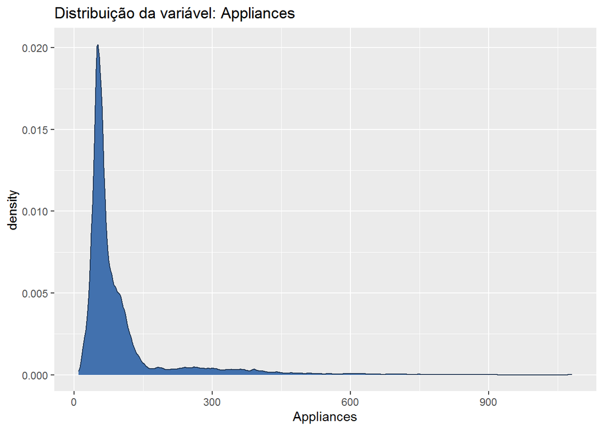

```r
dist_plot(data = df_train, col = 'Appliances')
```

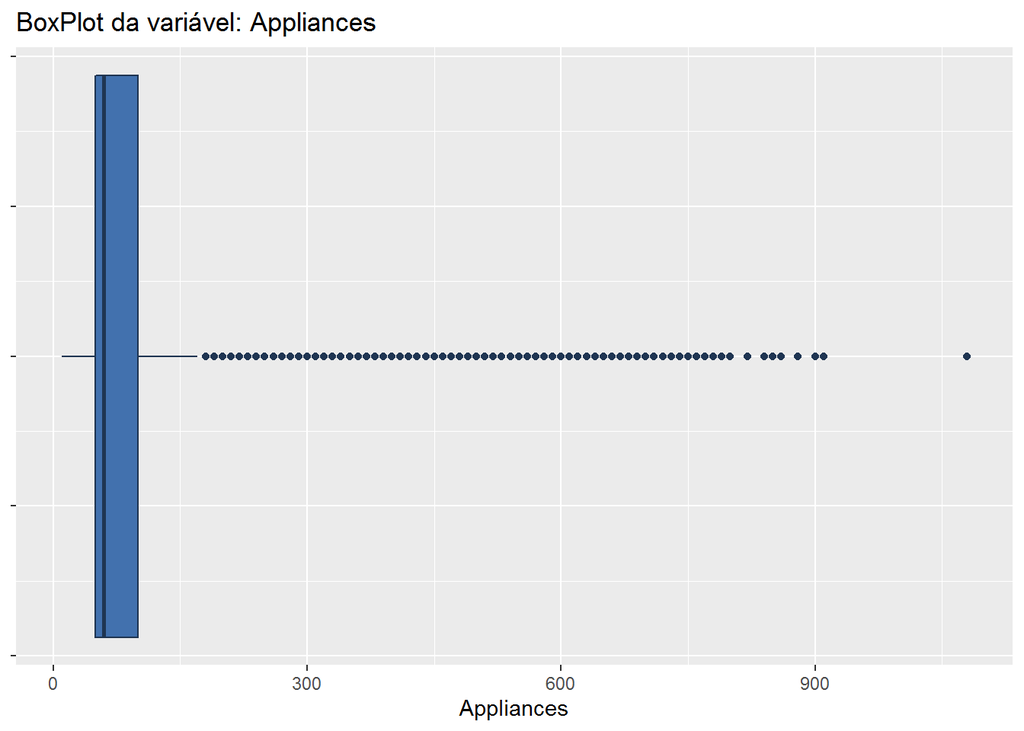

```r
box_plot(data = df_train,col = 'Appliances')
```

Com o distplot podemos ver uma assimetria nos dados, onde se encontram mais na parte esquerda, e com a ajuda do boxplot podemos também ver isso assim como a identificação de valores outliers que deveram ser tratados antos da aplicação dos modelos.

#### lights

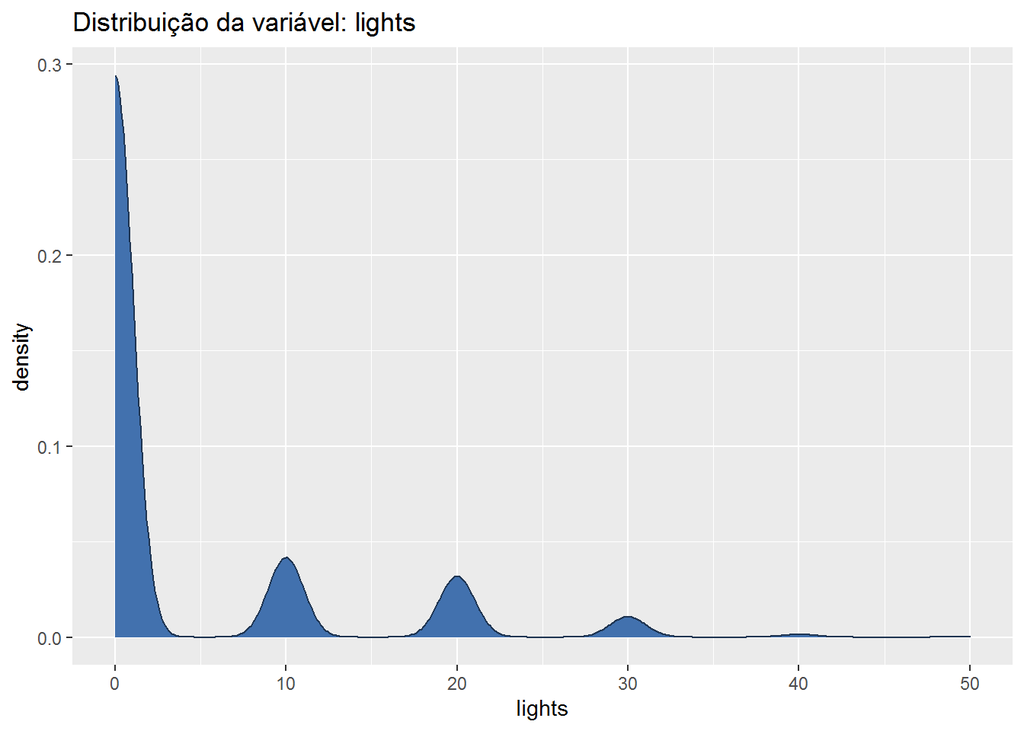

```r
dist_plot(data = df_train, col = 'lights')
```

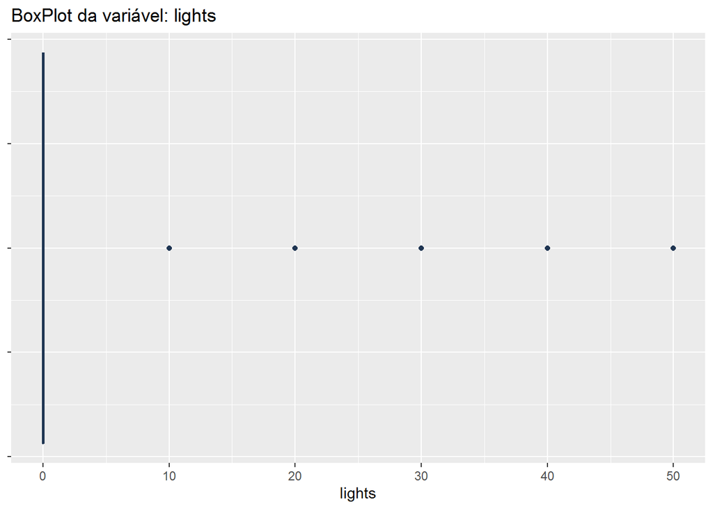

```r
box_plot(data = df_train,col = 'lights')
```

Com o distplot podemos ver uma assimetria nos dados, onde basicamente todos os valores estão próximos de 0 , e com a ajuda do boxplot podemos constatar que não possuem muitos valores outliers.

#### T1

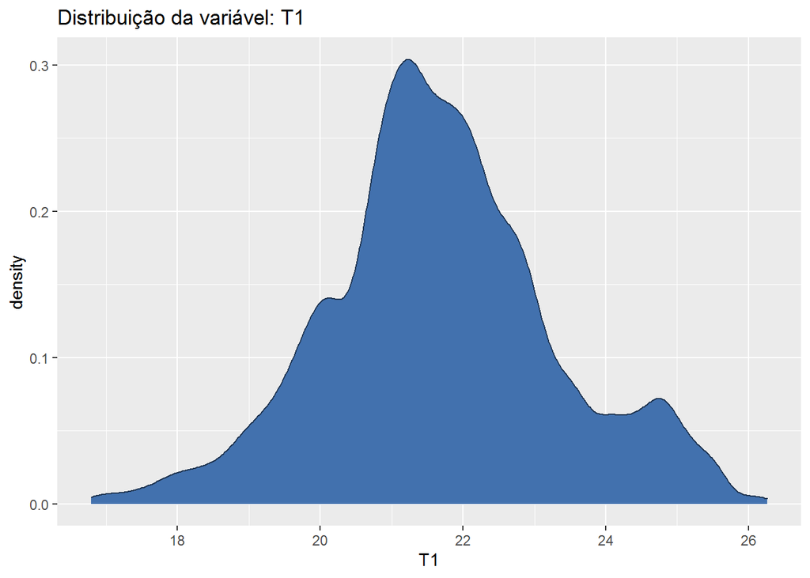

```r
dist_plot(data = df_train, col = 'T1')
```

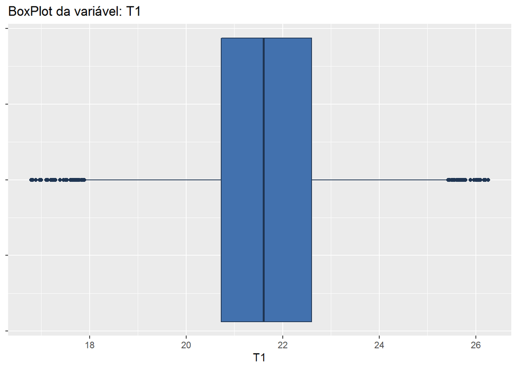

```r
box_plot(data = df_train,col = 'T1')
```

Com o distplot podemos ver que os dados estão quase simétricos apenas com algumas variações, e podemos ver com o boxplot outliers tanto na borda esquerda quando na direita.

#### RH_1

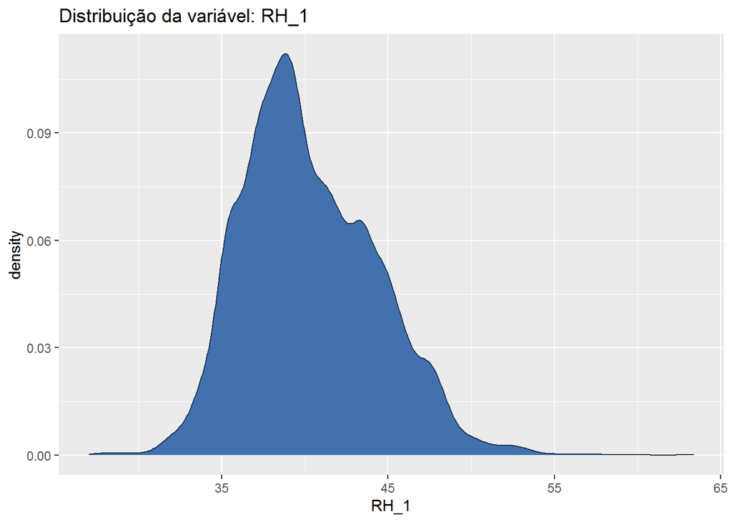

```r
dist_plot(data = df_train, col = 'RH_1')
```

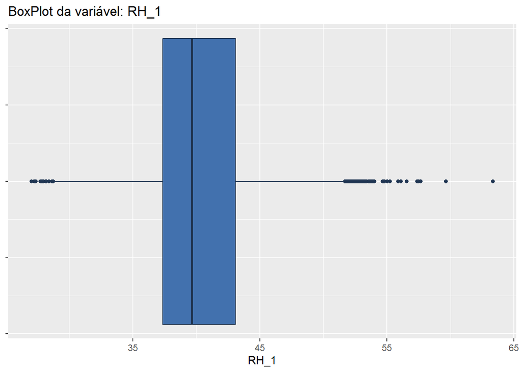

```r
box_plot(data = df_train,col = 'RH_1')
```

Com o distplot podemos ver que os dados estão quase simétricos apenas com algumas variações, e podemos ver com o boxplot outliers tanto na borda esquerda quando na direita.

#### T2

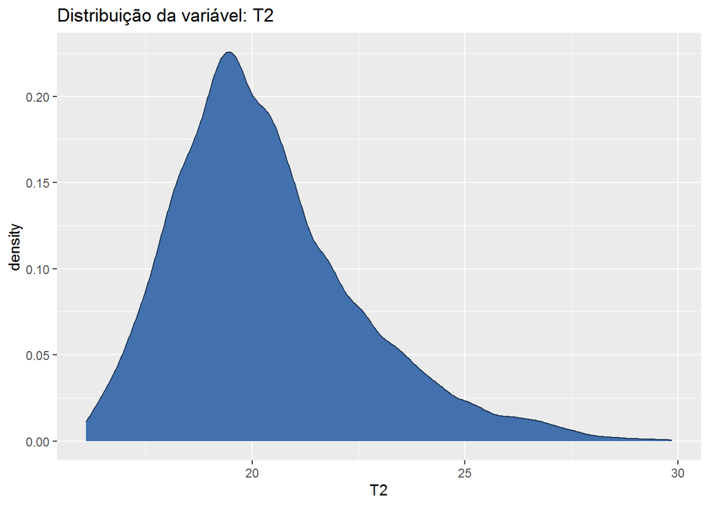

```r
dist_plot(data = df_train, col = 'T2')
```

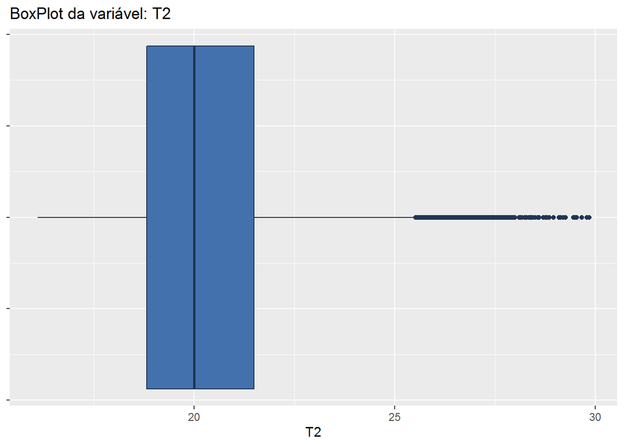

```r
box_plot(data = df_train,col = 'T2')
```

Com o distplot podemos ver que os dados um pouco mais concentrados a esquerda, porem quase simétrico, e com o boxplot constatamos alguns outliers na borda direita.

#### RH_2

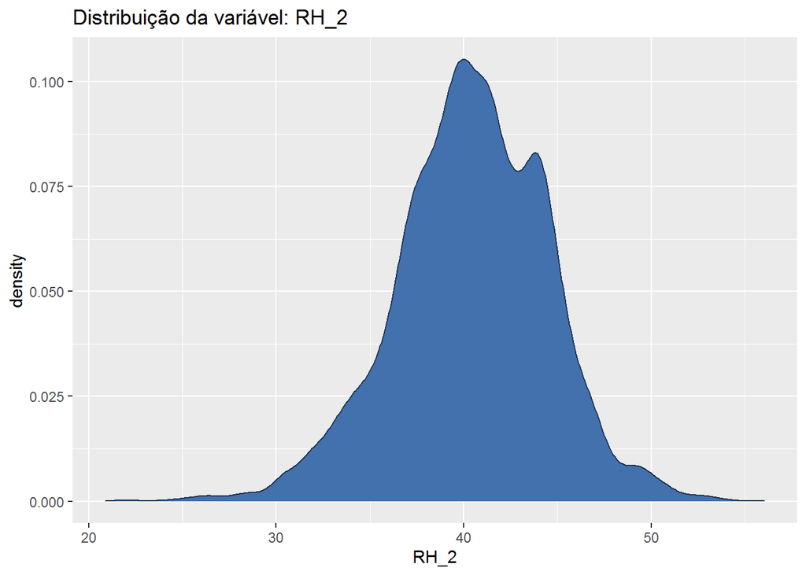

```r
dist_plot(data = df_train, col = 'RH_2')
```

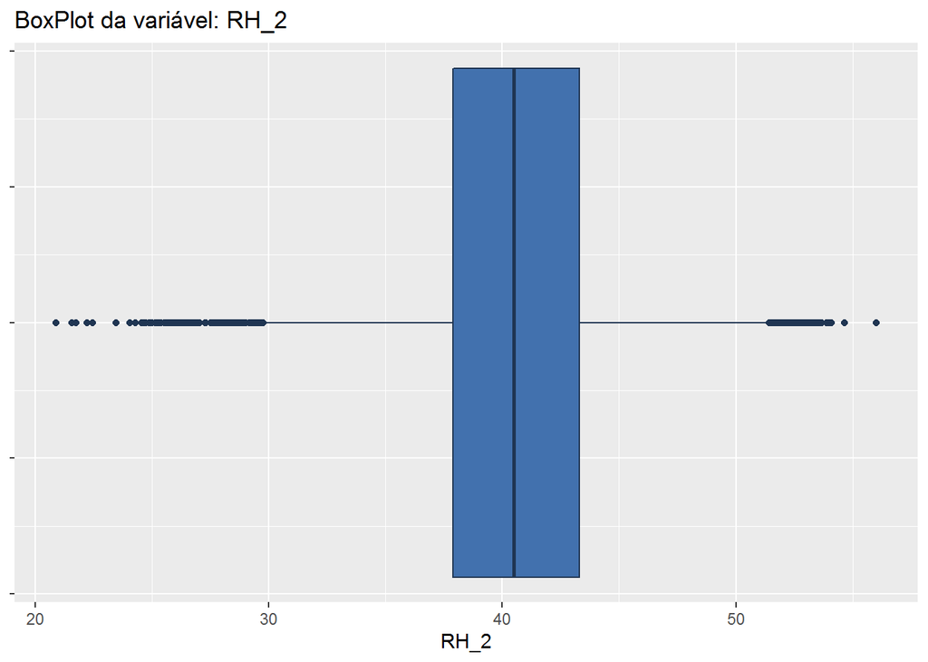

```r
box_plot(data = df_train,col = 'RH_2')
```

Com o distplot podemos ver que os dados estão quase simétricos apenas com algumas variações, e podemos ver com o boxplot outliers tanto na borda esquerda quando na direita.

#### T3

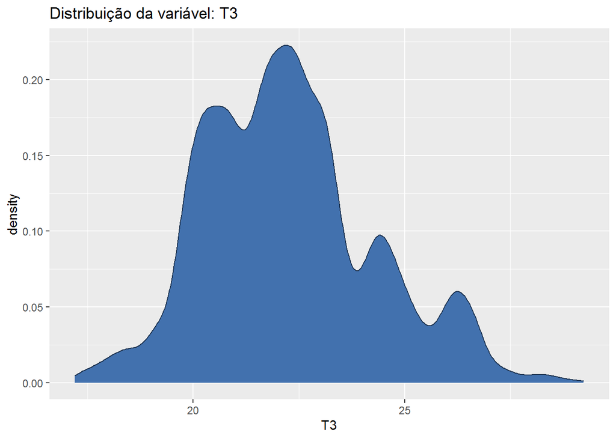

```r
dist_plot(data = df_train, col = 'T3')
```

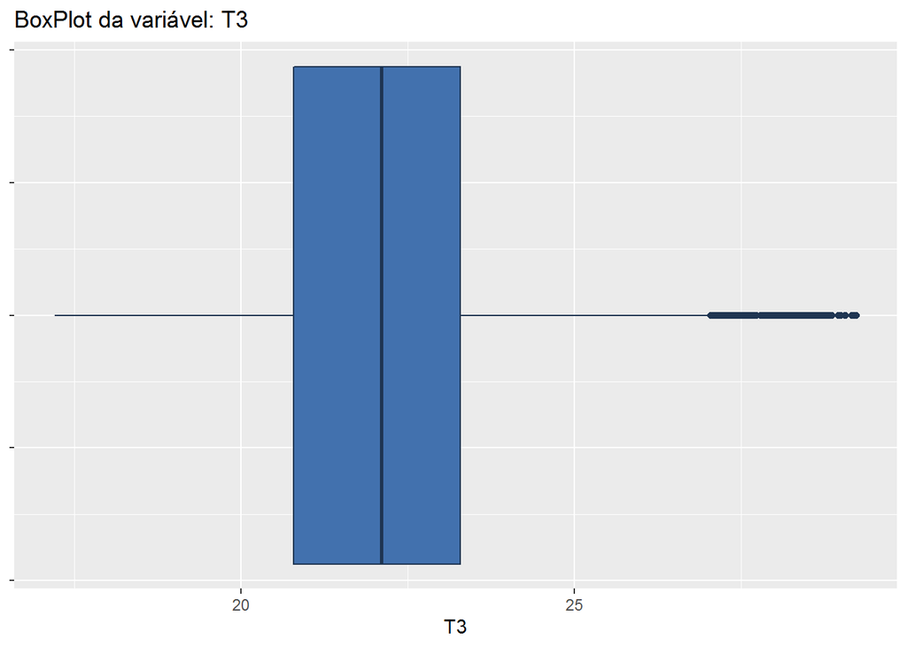

```r
box_plot(data = df_train,col = 'T3')
```

Com o distplot podemos ver que os dados estão bem distribuídos e com o boxplot temos alguns outliers na borda direita.

#### RH_3

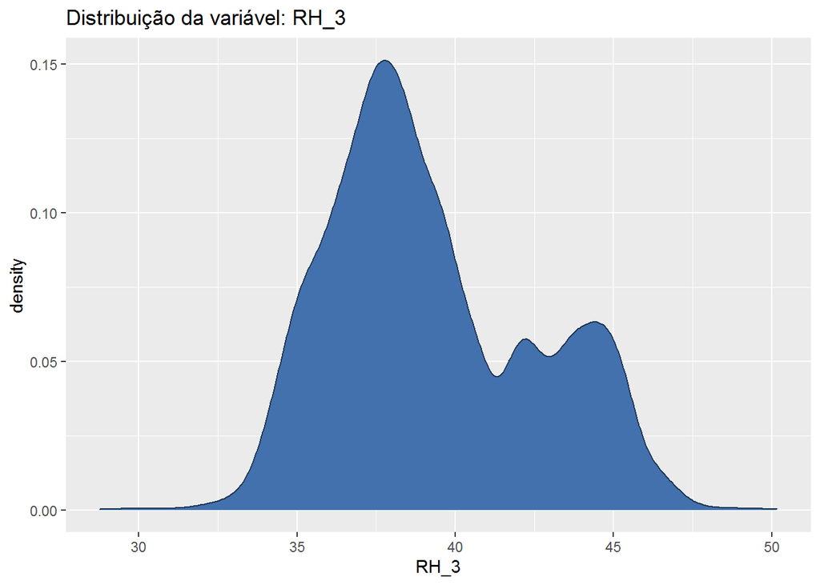

```r
dist_plot(data = df_train, col = 'RH_3')
```

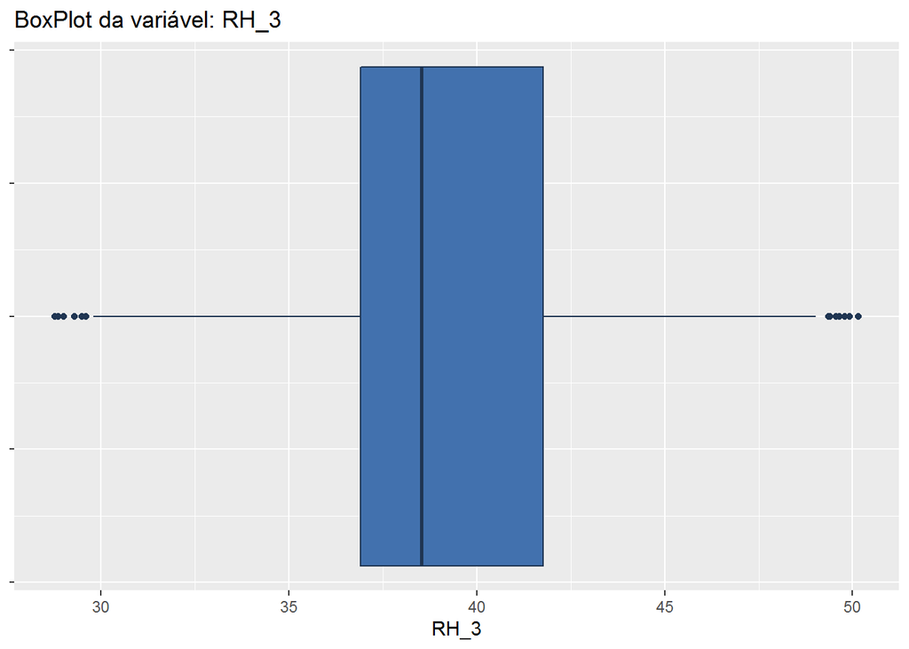

```r
box_plot(data = df_train,col = 'RH_3')
```

Com o distplot podemos ver que duas caudas nos dados uma um pouco mais acentuada e outra um pouco menor e com o boxplot podemos ver que existe poucos outliers

#### T4

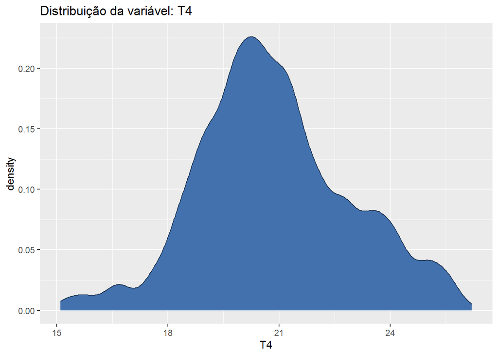

```r
dist_plot(data = df_train, col = 'T4')
```

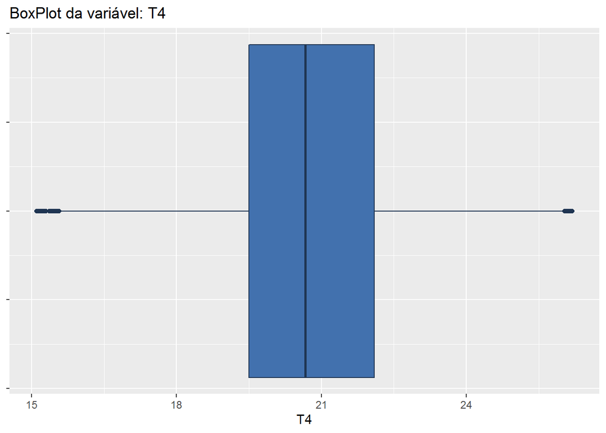

```r
box_plot(data = df_train,col = 'T4')
```

Com o distplot podemos ver que os dados estão quase simétricos apenas com algumas variações, e podemos ver com o boxplot alguns outliers tanto na borda esquerda quando na direita.

#### RH_4

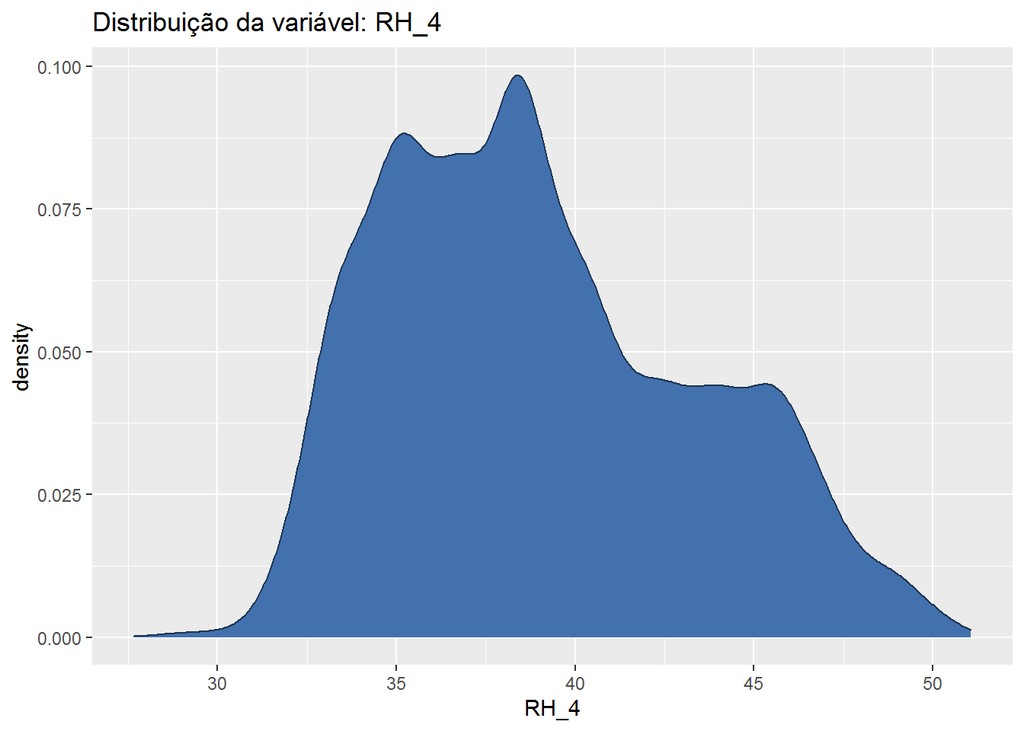

```r
dist_plot(data = df_train, col = 'RH_4')
```

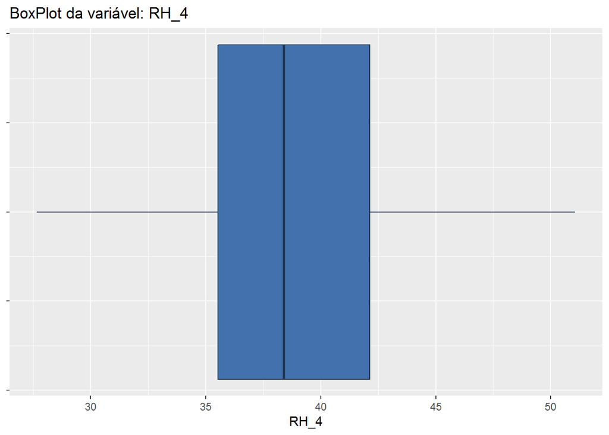

```r
box_plot(data = df_train,col = 'RH_4')
```

Com o distplot podemos ver que os dados estão bem distribuídos e por isso não á nenhum outliers como visto no boxplot.

#### T5

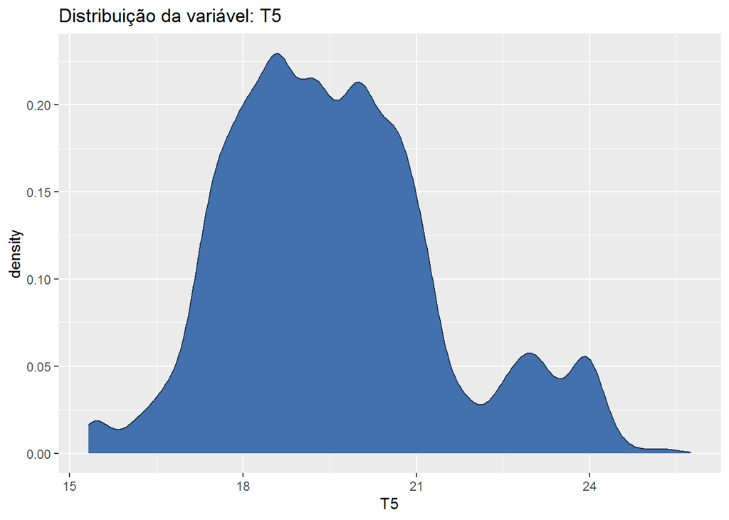

```r
dist_plot(data = df_train, col = 'T5')
```

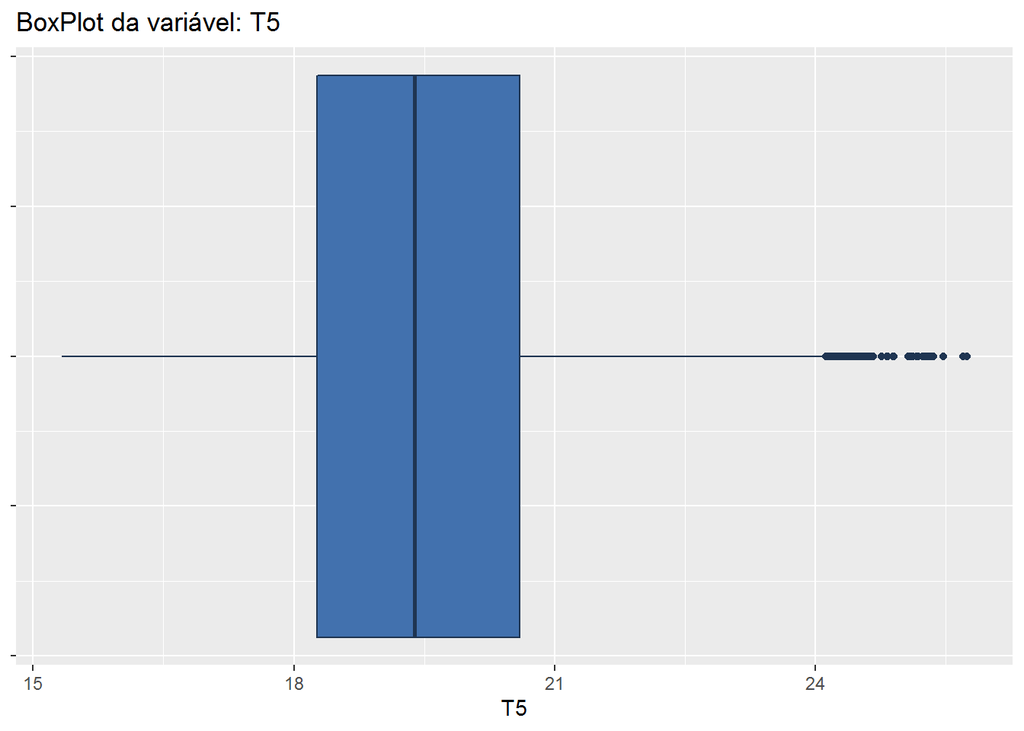

```r
box_plot(data = df_train,col = 'T5')
```

Com o distplot podemos ver que os dados estão quase simétricos e poucos outliers na borda direita como visto no boxplot.

#### RH_5

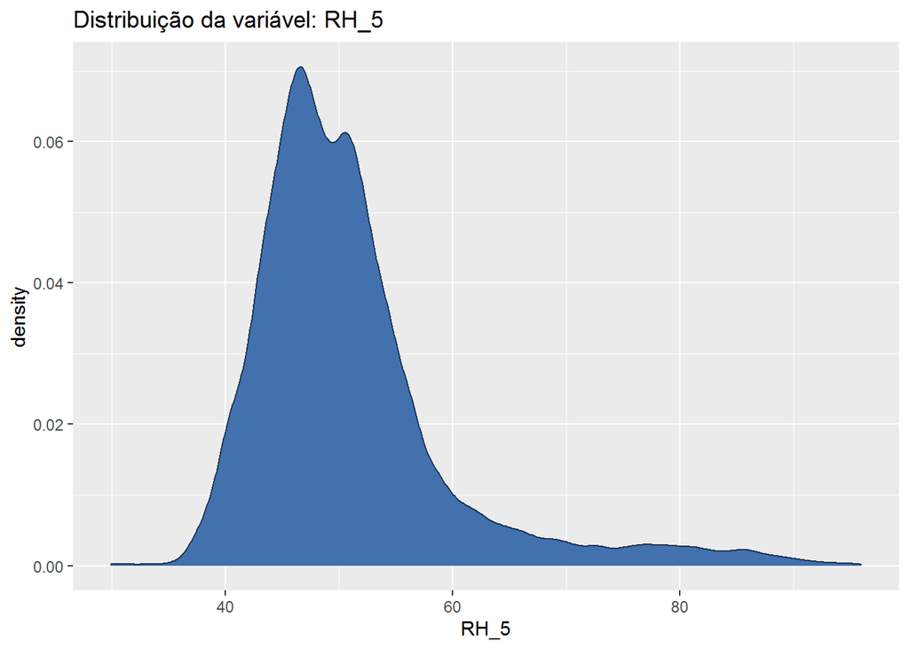

```r
dist_plot(data = df_train, col = 'RH_5')
```

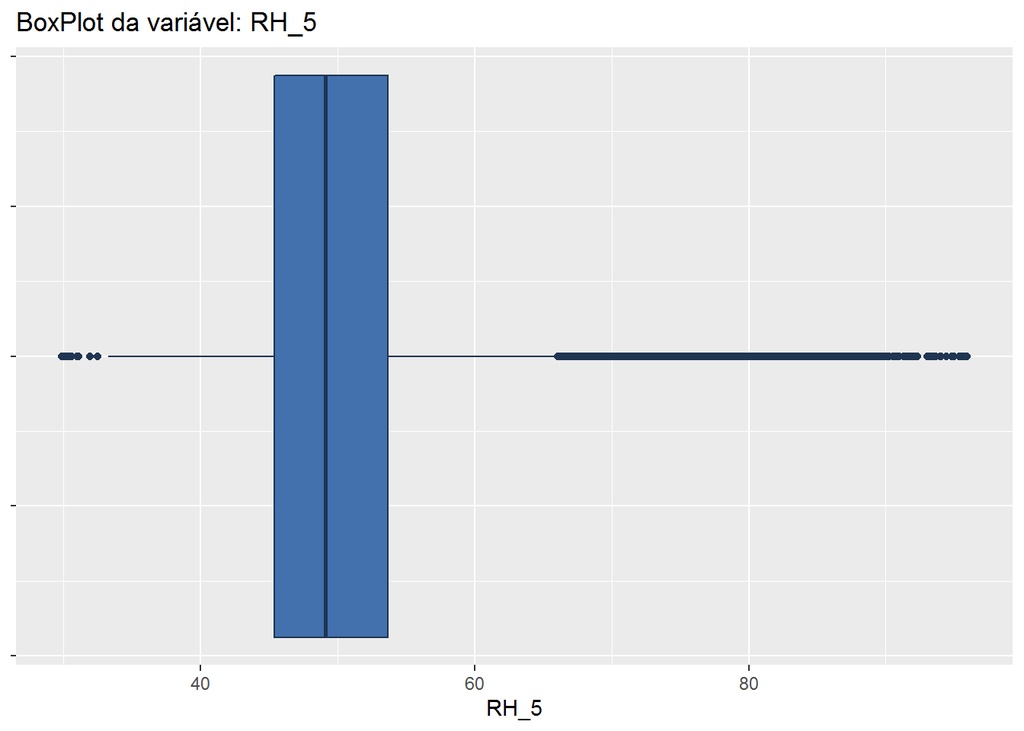

```r
box_plot(data = df_train,col = 'RH_5')
```

Com o distplot podemos ver que os dados tendem um pouco a esquerda, e tempos alguns outliers como visto com o boxplot, sobretudo na boda direita.

#### T6

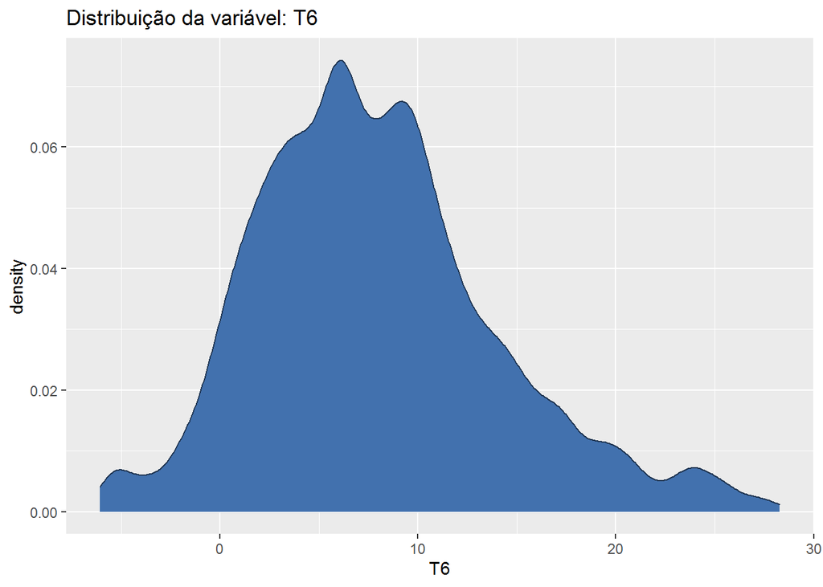

```r
dist_plot(data = df_train, col = 'T6')
```

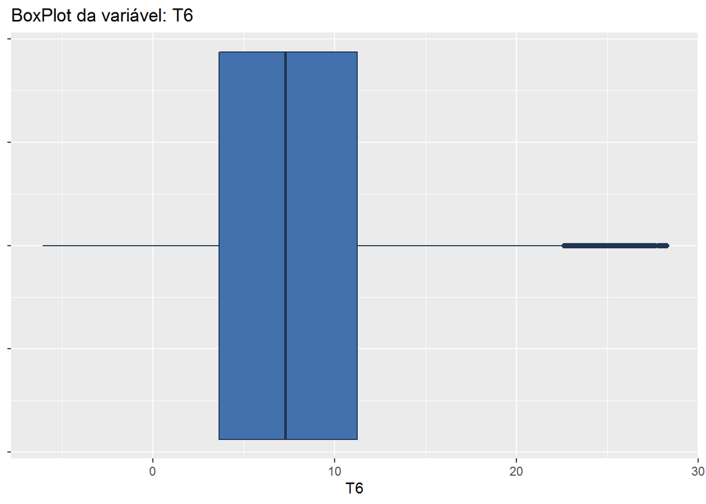

```r
box_plot(data = df_train,col = 'T6')
```

Com o distplot podemos ver que os dados estão bem distribuídos e com o boxplot temos alguns outliers na borda direita.

#### RH_6

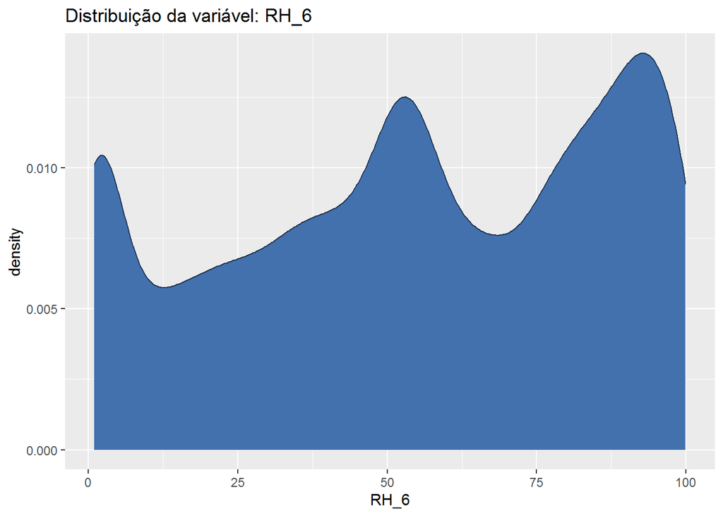

```r
dist_plot(data = df_train, col = 'RH_6')
```

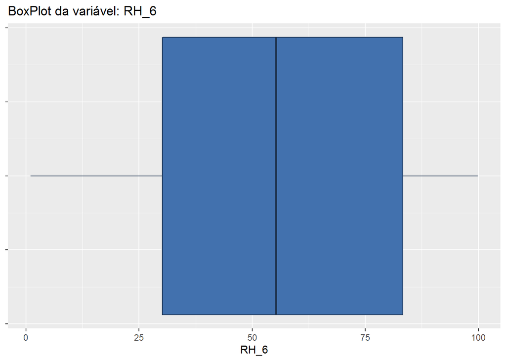

```r
box_plot(data = df_train,col = 'RH_6')
```

Com o distplot podemos ver que os dados estão totalmente distribuídos e nenhum outlier

#### T7

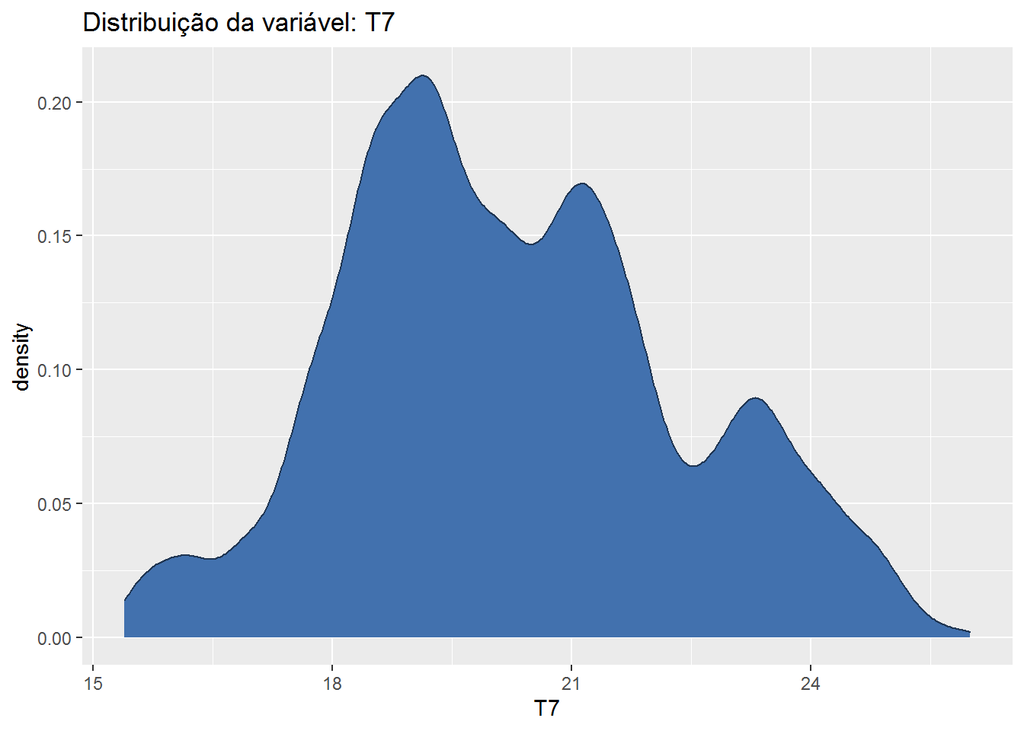

```r
dist_plot(data = df_train, col = 'T7')
```

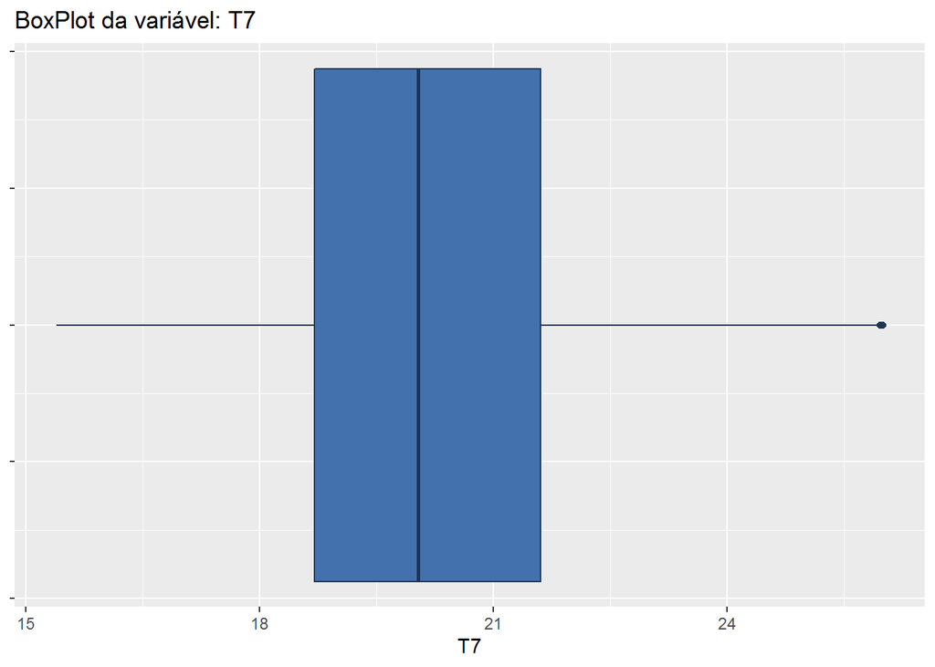

```r
box_plot(data = df_train,col = 'T7')
```

Com o distplot podemos ver que os dados estão bem distribuídos e poucos outliers

#### RH_7

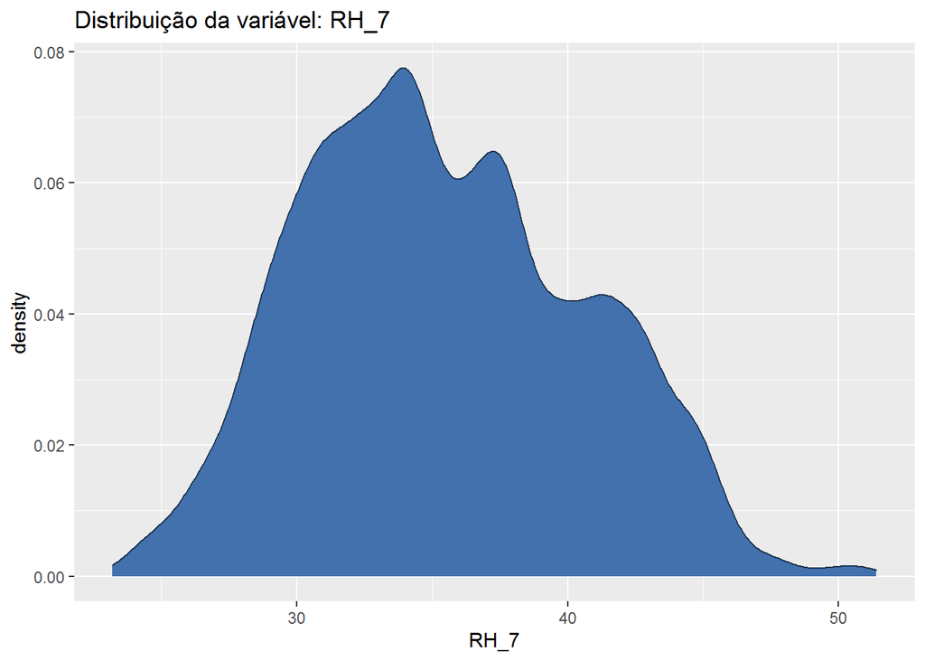

```r
dist_plot(data = df_train, col = 'RH_7')
```

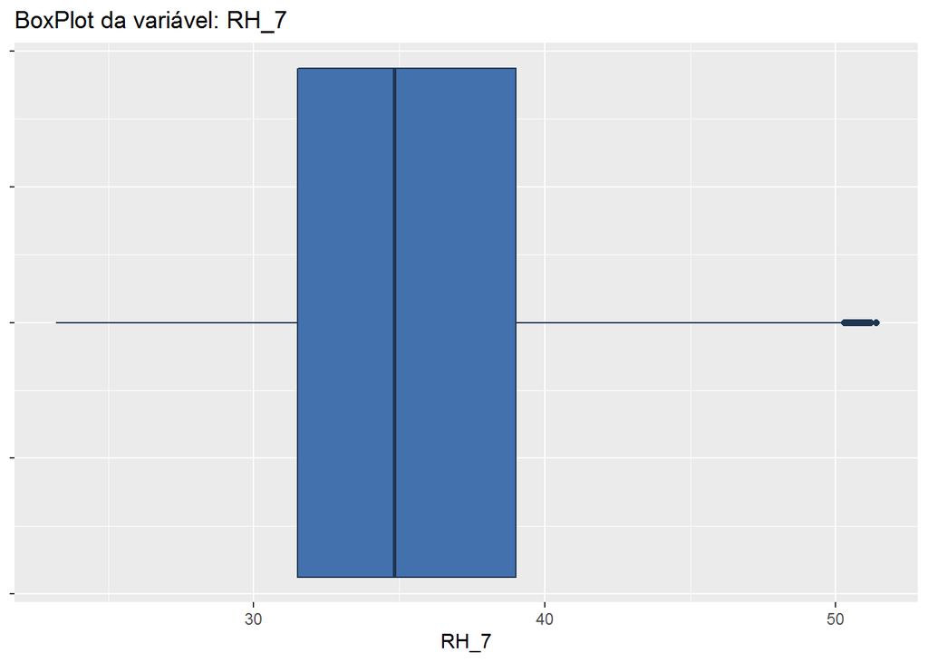

```r
box_plot(data = df_train,col = 'RH_7')
```

Com o distplot podemos ver que os dados estão bem distribuídos e poucos outliers